# FinalProject

Andrew Mikolinski

2023-12-05

# Introduction

## It is very well understood that plant diversity for a region of a given size varies from one geographic area to another. One very well documented trend of biodiversity is that the species richness of a given area decreases on a latitudinal gradient, with the greatest biodiversity found closer to the equator and the least biodiversity closer to the north and south poles (Mittelbach et al., 2007). With a wide variety of different environments and unique biomes, the United States likely exhibits strong diversity gradients both along a latitudinal gradient and between environment types. These patterns may determine the geographic patterns of dicot plant species richness across the country.

## While significant research has been done on the latitudinal gradient of species diversity, the explanations of these mechanisms are not purely attributed to latitude. Macroecological explanations for the decrease in species richness on a latitudinal gradient therefore focus on covariates of latitude such as habitat diversity (Rosenzweig, 1995) and climate (Currie et al., 2004). Relatively few studies have attempted to isolate the differential impacts of latitude on species richness from the impacts of environmental conditions. Such an analysis may provide insight into the patterns of species migration down a latitudinal gradient and speciation following the last ice age. There is a significant amount of location data for the thousands of different species that can be found in the United States some of which can be acquired through the online database GBIF. The ultimate goal of this study is to separate the effects of differences in environmental and climatic conditions associated with each biome and assess the impacts purely of latitude on species richness.

## Biome type and latitude are integrally correlated because average annual temperatures decrease with increasing distance from the equator as does seasonal habitat variation in the United States. Therefore, it will be difficult to fully separate the impacts of biome type and latitude. As a result, this project will assess the interaction of biome types and latitude, in addition to assessing the impacts of biome type and latitude on species richness individually. I predict that I will find a significant impact of the interaction between latitude and biome on Shannon diversity index values as well as a significant impact of both biome and latitude individually. I also predict, that out of these the two explanatory variables and the interaction term, I will find that latitude has a more significant negative relationship with species richness than biome type overall.

# Dataset Description

## The dataset used in this study consisted of all research grade iNaturalist observations of dicot plant species in the congenital United States, accessed through the GBIF online archive. iNaturalist considers only the observations that have been identified to the species level by multiple parties to be research grade observations. Each observation consists of the taxonomic information for the species observed as well as the coordinates of the observation. Not all location data is exact, and the platform provides the coordinate uncertainty in meters for each observation. The location uncertainty of the majority of observations is relatively small (3m-10m), but all observations where the uncertainty was greater than 100 meters were excluded from this study. Also excluded from this study were all data at latitudes lower than N 30.00000 because the only regions of the United States below this latitude are the southern tip of Texas and much of Florida. The data below N 30.0000 were excluded from this study for several reasons :

### 1) Compared to the sizes of the other datasets, there were relatively few observations in these regions.

### 2) Southern Florida consists ofmultiple unique biomes which do not have similar counterparts anywhere else in the United States, making comparisons of species diversity between latitudes and biomes fallible.

### 3) This study is limited by computational power, and it was best to remove any data that may not be necessary from computations.

## All observations of plants from all dicot orders which fit the above criteria were included in this study.In all, the dataset used consisted of over 6 million datapoints of observations of plants from 36 different orders. This dataset was compiled into 10 data frames using the application R, with each data frame consisting of all observations within a specified 2-degree latitude band, starting with all observations between N 30.000000 and N 32.000000, between N 32.000001 and N 34.000000, and so on until the 50thdegree of latitude.

# Statistical Models and Methods

## Hypothesis testing:

### Hypothesis testing is performed in the context of this study to identify whether there was a significant difference between Shannon diversity index values across different biomes and different latitudes. Hypothesis testing refers to the use of a test statistic and a specific alpha level to determine the probability that the null hypothesis is true given the data. The null hypothesis represents the situation where the explanatory variables do not have an impact on the response variable. The alternative hypothesis is a statement that contradicts the null hypothesis. If the p-value is smaller than the chosen significance level, it means that the differences in the data likely occurred as a result of the explanatory variables having a statistically significant impact on the response variable. If this is the case, the null hypothesis can be rejected, and the alternative hypothesis is valid.

## QQ Plot for Normalcy Test:

### A QQ plot is a graphical tool that is used to assess whether the quantiles of the observed data align with the theoretical quantiles of a normally distributed dataset. To construct a QQ plot, the data are arranged in ascending order and the corresponding quantiles of each datapoint are calculated. Then the quantiles of the observed data are plotted with their corresponding theoretical quantiles on the graph with a reference line. The reference line shows what a normally distributed dataset will look like, so ideally the points on the graph will match up closely with the reference line. If they do not then a transformation will be needed. The QQ plot is important because many statistical methods assume normality in the data, or normality of residuals.

## Linear Regression:

### Linear regression is a type of statistical method that is used for modeling the relationship between the response variable and at least one (but often multiple) explanatory variables. The goal of linear regressions is to quantify the relationship between the variables. Linear modeling provides the coefficient $\beta$<sub>1</sub> which describes the slope of the regression. $\beta$<sub>1</sub> is important because if it is a positive number, it would mean that the relationship between the explanatory and response variables is also positive. This means that an increase in the value of the explanatory variable by one unit tends to lead to lead to an increase in the response variable by a number of units equal to the absolute value of $\beta$<sub>1</sub>. Similarly, if $\beta$<sub>1</sub> is negative, then an increase in the explanatory variable tends to lead to a decrease in the response variable. A critical assumption of linear regressions is that the residuals are normally distributed. If residuals are not normally distributed, then the data will have to be transformed in order to make them normally distributed.

## ANOVA:

### ANOVA, or Analysis of Variance, is a type of statistical technique that is used to compare the means of two or more populations of data to determine if the differences between them are statistically significant. ANOVA is particularly useful if there are more than two groups, as it provides a way to examine the variability between and among populations. ANOVA uses the F-statistic, which shows the ratio of the variance between groups to the variance within groups. A high F-statistic suggests that the population means are statistically different from each other. The critical assumption of ANOVA is that the variances within groups are approximately equal, if there is evidence that this assumption is not satisfied then the results of ANOVA are not reliable. Another assumption of ANOVA is that the populations are approximately normally distributed. In the context of a linear regression, it is less important that the data are normally distributed, and more important that the residuals are normally distributed.

## Shannon Diversity Index:

### The Shannon diversity index is a technique used in ecology to quantify the species richness of a given region. The index considers both the number of species and the relative abundances of each species. Populations of rarer species are therefore given less weight in the Shannon Diversity Index than populations of common species. A high Shannon Diversity Index value means that the ecological community in question has very high species richness and that the number of individuals of each species is relatively even. The Shannon Diversity index is given by the equation:

#### H = - $\sum$<sup>S</sup><sub>i=1</sub>=pi*ln(pi)

### Where:

#### H is the Shannon Diversity Index value

#### S is the total number of species living in the community

#### p<sub>i</sub> is the proportion of individuals belonging to the i<sup>th</sup> species in the community.

### There are a few limitations to using the Shannon Diversity Index.Shannon Diversity Indices are sensitive to sample sizes, small sample sizes may produce an inflated Shannon Diversity Index value for the community. The Shannon Diversity index is not sensitive to species identity, it treats all species as equivalent so the Shannon value tells us nothing about the composition of the community, it is just a measure of how many species there are and how they’re distributed. It also assumes that all observations of species are independent of each other, which may not always be the case (Shannon, 1948).

# Analysis and Results:

## Hypothesis testing was performed to determine the influence that latitude has on Shannon Diversity index values. Additionally, species richness can vary significantly between biome types as a result of environmental conditions. Without analyzing the impact of biome type on species richness, an increase or decrease in richness as a result of biome type may be mistaken as an increase or decrease in species richness as a result of latitude. Linear regression models make it much easier to separate the effects of the biome variable from the effects of the latitude variable. Therefore, the two explanatory variables used in this study were latitude and biome. All computations were done using the R software. Both confidence levels $\alpha$ = 0.1 and $\alpha$ = 0.05 are used and referenced in this study. P-values < 0.1 are only considered marginally significant and p-values < 0.05 is considered significant. The hypotheses tested in this study were:

### H<sub>0</sub>: Shannon diversity index values do not decrease significantly with increasing latitude across biomes in the United States.

#### $\beta$<sub>1</sub>=0

### H<sub>A</sub>: Shannon diversity index values significantly decrease with increasing latitude across biomes in the United States.

#### $\beta$<sub>1</sub><0

## In order for inferences to be made based on a standard linear regression and ANOVA, normality of residuals is important. Before proceeding, it was noted that the data was significantly left skewed, therefore, the data were transformed using the exp() function in R to make the data appear more normal (Figure1). Please note that while the QQplot below is for all datapoints in the entire dataset, all of the data for each of the broader biome types were transformed in this way too, and the QQ plot created for each of them displayed similarly normal residual distributions. While there is some variability around the extreme high and extreme low ends of the QQplot, indicating the presence of outliers, the residuals of the data appear to follow a normal distribution. Additionally, a Residuals vs Fitted plot was generated to determine visually if the homogeneity of variance assumption was violated and there appeared to be no significant visual patterns in the graph that would cause me to believe that this assumption was violated.

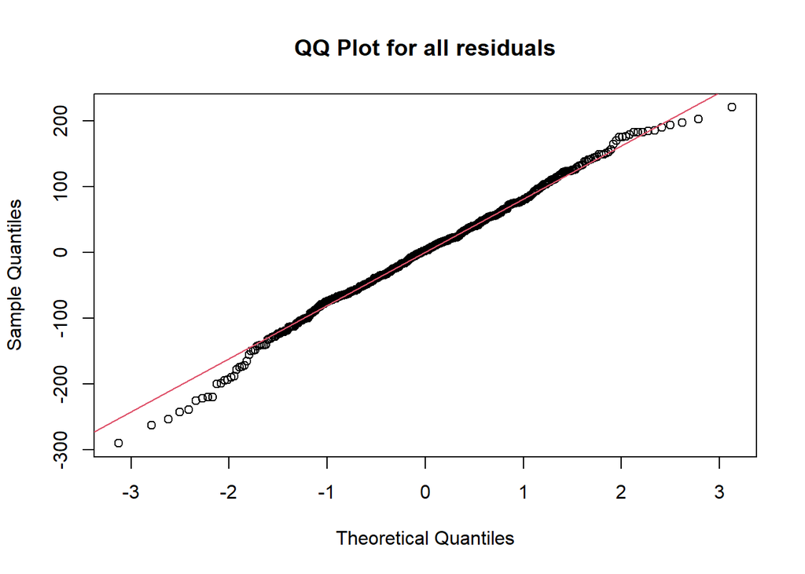

```r
all2$biome <- factor(all2$biome)
all2$biome <- relevel(all2$biome, ref = "Southeastern Mixed Forest")

all2$lat <- as.numeric(all2$lat)
modelall <- gen_m0(all2)
model1 <- aov(Shannon~lat+biome+lat*biome, data = all2)
Residuals_all <- residuals(model1)
qqnorm(Residuals_all, main="QQ Plot for all residuals")
qqline(Residuals_all, col = 2)
```

```r
model <- aov(Shannon ~ lat+biome+lat*biome, data = all2)
```

```r
Table1 <- anova(model1)
Table1
```

```
## Analysis of Variance Table
##
## Response: Shannon
##            Df  Sum Sq Mean Sq F value    Pr(>F)
## lat         1  104435  104435 13.3610 0.0002833 ***
## biome      25 3033403  121336 15.5233 < 2.2e-16 ***
## lat:biome  24  321088   13379  1.7116 0.0195684 *
## Residuals 515 4025446    7816
## ---
## Signif. codes:  0 '***' 0.001 '**' 0.01 '*' 0.05 '.' 0.1 ' ' 1
```

## As shown in the ANOVA table above, the p-value generated for latitude overall is highly significant (p = 0.000), and the calculated value for $\beta$<sub>1</sub> was -2.800246 (Table 7). This suggests that latitude does have a significant negative impact on $\beta$<sub>1</sub> overall. The null hypothesis can therefore be rejected based on the overall data. It is interesting to note, however, that while the impacts of both latitude and biome are significant, the interaction term between latitude and biome is significant (p <0.05).

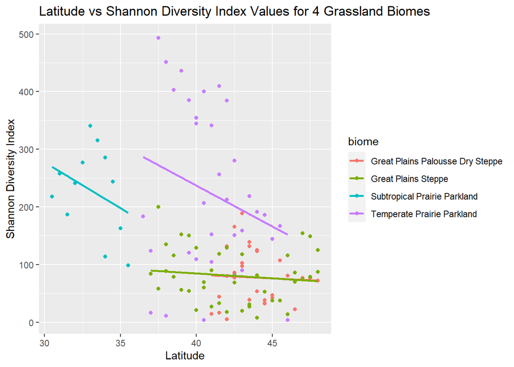

```r
SLmodelG<-gen_m0(G)
modelG <- aov(Shannon~lat+biome+lat*biome, data = G)
Table2<-anova(modelG)
plotG <- ggplot(G, aes(x= lat, y = Shannon, color = biome)) +
  geom_point() +
  geom_smooth(method = "lm", se=FALSE, aes(group=biome)) +
  xlab("Latitude") +
  ylab("Shannon Diversity Index") +
  ggtitle("Latitude vs Shannon Diversity Index Values for 4 Grassland Biomes")
plotG
```

```r
Table2
```

```
## Analysis of Variance Table
##
## Response: Shannon
##            Df Sum Sq Mean Sq F value    Pr(>F)
## lat         1 246695  246695 32.2572 1.134e-07 ***
## biome       3 363649  121216 15.8500 1.273e-08 ***
## lat:biome   3  27054    9018  1.1792    0.3211
## Residuals 109 833603    7648
## ---
## Signif. codes:  0 '***' 0.001 '**' 0.01 '*' 0.05 '.' 0.1 ' ' 1
```

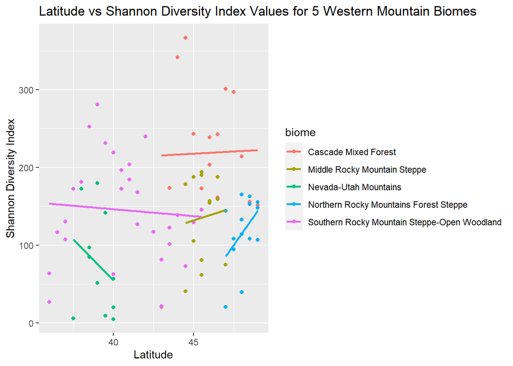

```r
SLmodelWM <- gen_m0(WM)
modelWM <- aov(Shannon~lat+biome+lat*biome, data = WM)
Table3<-anova(modelWM)


plotWM <- ggplot(WM, aes(x= lat, y = Shannon, color = biome)) +
  geom_point() +
  geom_smooth(method = "lm", se=FALSE, aes(group=biome)) +
  xlab("Latitude") +
  ylab("Shannon Diversity Index") +
  ggtitle("Latitude vs Shannon Diversity Index Values for 5 Western Mountain Biomes")
plotWM
```

```r
Table3
```

```
## Analysis of Variance Table
##
## Response: Shannon
##           Df Sum Sq Mean Sq F value    Pr(>F)
## lat        1  13314   13314  2.9581   0.08974 .
## biome      4 134028   33507  7.4443 4.472e-05 ***
## lat:biome  4   9271    2318  0.5149   0.72496
## Residuals 72 324073    4501
## ---
## Signif. codes:  0 '***' 0.001 '**' 0.01 '*' 0.05 '.' 0.1 ' ' 1
```

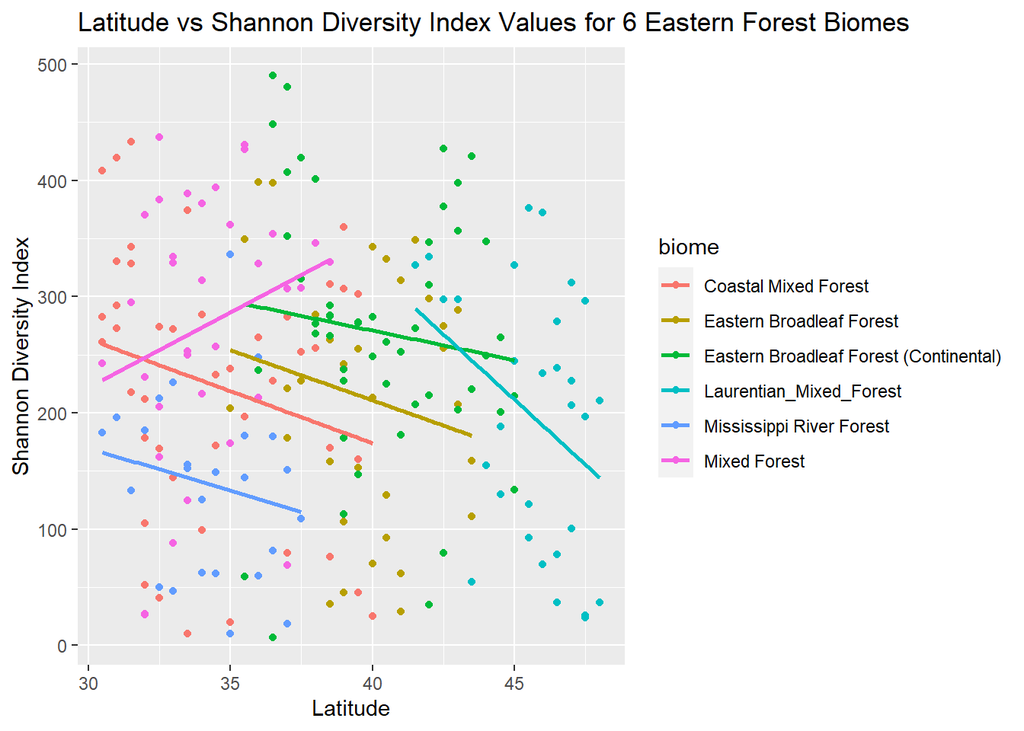

```r
SLmodelEF<- gen_m0(EF)
modelEF <- aov(Shannon~lat+biome+lat*biome, data = EF)
Table4<-anova(modelEF)
plotEF <- ggplot(EF, aes(x= lat, y = Shannon, color = biome)) +
  geom_point() +
  geom_smooth(method = "lm", se=FALSE, aes(group=biome)) +
  xlab("Latitude") +
  ylab("Shannon Diversity Index") +
  ggtitle("Latitude vs Shannon Diversity Index Values for 6 Eastern Forest Biomes")
plotEF
```

```r
Table4
```

```
## Analysis of Variance Table
##
## Response: Shannon
##            Df  Sum Sq Mean Sq F value    Pr(>F)
## lat         1   15506   15506  1.3622    0.2445
## biome       5  438490   87698  7.7042 1.167e-06 ***
## lat:biome   5   78704   15741  1.3828    0.2321
## Residuals 205 2333552   11383
## ---
## Signif. codes:  0 '***' 0.001 '**' 0.01 '*' 0.05 '.' 0.1 ' ' 1
```

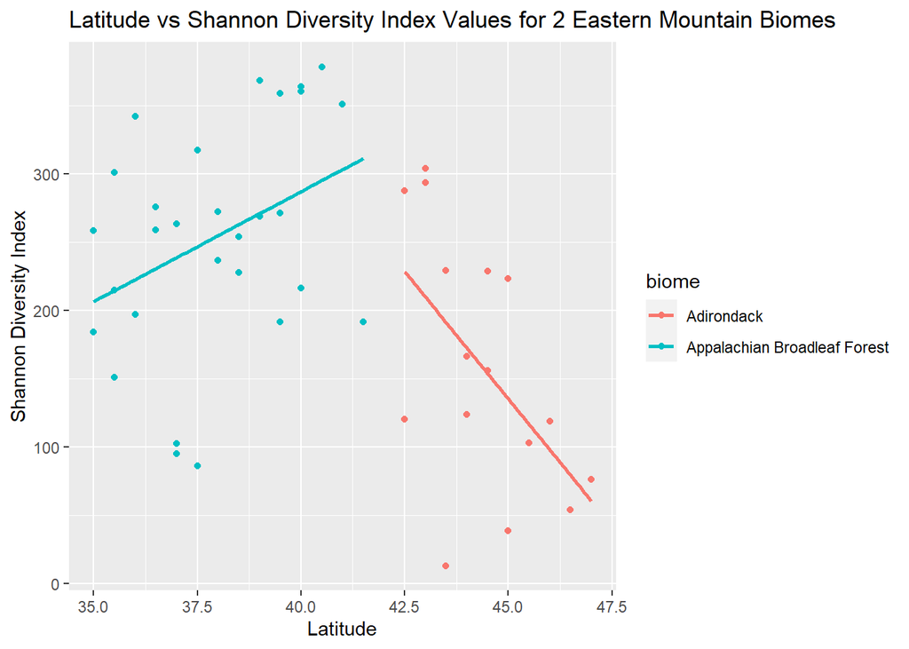

```r
SLmodelEM<-gen_m0(EM)
modelEM <- aov(Shannon~lat+biome+lat*biome, data = EM)
Table5<-anova(modelEM)
plotEM <- ggplot(EM, aes(x= lat, y = Shannon, color = biome)) +
  geom_point() +
  geom_smooth(method = "lm", se=FALSE, aes(group=biome)) +
  xlab("Latitude") +
  ylab("Shannon Diversity Index") +
  ggtitle("Latitude vs Shannon Diversity Index Values for 2 Eastern Mountain Biomes")
plotEM
```

```r
Table5
```

```
## Analysis of Variance Table
##
## Response: Shannon
##           Df Sum Sq Mean Sq F value   Pr(>F)
## lat        1  59549   59549  9.4221 0.003793 **
## biome      1  36356   36356  5.7523 0.021101 *
## lat:biome  1  63866   63866 10.1051 0.002812 **
## Residuals 41 259127    6320
## ---
## Signif. codes:  0 '***' 0.001 '**' 0.01 '*' 0.05 '.' 0.1 ' ' 1
```

[figure not shown]

```r
SLmodelD <- gen_m0(D)
modelD <- aov(Shannon~lat+biome+lat*biome, data = D)
Table6<-anova(modelD)
plotD <- ggplot(D, aes(x= lat, y = Shannon, color = biome)) +
  geom_point() +
  geom_smooth(method = "lm", se=FALSE, aes(group=biome)) +
  xlab("Latitude") +
  ylab("Shannon Diversity Index") +
  ggtitle("Latitude vs Shannon Diversity Index Values for 7 Desert Biomes")
plotD
```

```r
Table6
```

```
## Analysis of Variance Table
##
## Response: Shannon
##            Df Sum Sq Mean Sq F value   Pr(>F)
## lat         1  13644 13644.0  3.2488 0.074030 .
## biome       5  72298 14459.6  3.4430 0.006113 **
## lat:biome   5  41303  8260.6  1.9669 0.088543 .
## Residuals 118 495570  4199.7
## ---
## Signif. codes:  0 '***' 0.001 '**' 0.01 '*' 0.05 '.' 0.1 ' ' 1
```

```
##                   Beta1_Latitude
## All.Biomes             -2.800246
## Grasslands            -11.545689
## Eastern.Forest         -1.803384
## Eastern.Mountains     -10.327927
## Western.Mountains       3.350643
## Desert                 -3.484803
```

# Discussion

## The source of the raw data used in this study is also potentially biased and incomplete. In order for an observation to be marked as research grade on iNaturalist, an observation of a particular plant species needs to be made. It is possible that one source of bias in this data comes from the “visibility” of species. Some plant species are large and produce very showy floral displays whereas others are relatively small and inconspicuous. Therefore, the data used in this study may be biased in favor of larger and showier species such as Helianthus species and therefore it could produce an inflated estimate of the relative abundance of Helianthus species. In contrast, the smaller and less conspicuous species such as those in the genus Polygala may be overlooked in the environment very easily, and the data may produce a deflated estimate of the abundance of such species.

# Conclusion

# References

## Currie, D.J., Mittelbach, G.G., Cornell, H.V., Field, R., Guégan, J.-F., Hawkins, B.A., 445 Kaufman, D.M., Kerr, J.T., Oberdorff, T., O’Brien, E. & Turner, J.R.G. (2004) 446 Predictions and tests of climate‐based hypotheses of broad‐scale variation 447 in taxonomic richness. Ecology Letters, 7, 1121-1134.

## Mittelbach, G.G., Schemske, D.W., Cornell, H.V., Allen, A.P., Brown, J.M., Bush, M.B., 490 Harrison, S.P., Hurlbert, A.H., Knowlton, N., Lessios, H.H., McCain, C.M., 491 McCune, A.R., McDade, L.A., McPeek, M.A., Near, T.J., Ricklefs, R.E., Roy, K., Sax, 492 D.F., Schluter, D., Sobel, J.M. & Turelli, M. Evolution and the latitudinal 493 diversity gradient: speciation, extinction and biogeography. Ecology Letters, 494, 315-331.

## Rosenzweig, M.L. (1995) Species Diversity in Space and Time. Cambridge University 502 Press, Cambridge, UK.

## Shannon, C.E.(1948) A mathematical theory of communication. The Bell System Technical Journal, 27, 372-423 and 623-656.

# GBIF Downloads:

## GBIF.org (8 October 2023) GBIF Occurrence Download https://doi.org/10.15468/dl.e3qgzs

## GBIF.org (8 October 2023) GBIF Occurrence Download https://doi.org/10.15468/dl.qfk9bf

## GBIF.org (8 October 2023) GBIF Occurrence Download https://doi.org/10.15468/dl.qfk9bf

## GBIF.org (8 October 2023) GBIF Occurrence Download https://doi.org/10.15468/dl.5fng8y

## GBIF.org (8 October 2023) GBIF Occurrence Download https://doi.org/10.15468/dl.4r9guh

## GBIF.org (8 October 2023) GBIF Occurrence Download https://doi.org/10.15468/dl.v9rpyc

## GBIF.org (8 October 2023) GBIF Occurrence Download https://doi.org/10.15468/dl.u24vwt

## GBIF.org (8 October 2023) GBIF Occurrence Download https://doi.org/10.15468/dl.sz6h3c

## GBIF.org (8 October 2023) GBIF Occurrence Download https://doi.org/10.15468/dl.737e9p

## GBIF.org (8 October 2023) GBIF Occurrence Download https://doi.org/10.15468/dl.bgxmvb

## GBIF.org (8 October 2023) GBIF Occurrence Download https://doi.org/10.15468/dl.f4rszx

## GBIF.org (8 October 2023) GBIF Occurrence Download https://doi.org/10.15468/dl.eakrjf

## GBIF.org (8 October 2023) GBIF Occurrence Download https://doi.org/10.15468/dl.uvsveh

## GBIF.org (8 October 2023) GBIF Occurrence Download https://doi.org/10.15468/dl.bcmzff

## GBIF.org (8 October 2023) GBIF Occurrence Download https://doi.org/10.15468/dl.v7kpsm

## GBIF.org (8 October 2023) GBIF Occurrence Download https://doi.org/10.15468/dl.zcj5s3

## GBIF.org (8 October 2023) GBIF Occurrence Download https://doi.org/10.15468/dl.sz8ddy

## GBIF.org (8 October 2023) GBIF Occurrence Download https://doi.org/10.15468/dl.fubjmj

## GBIF.org (8 October 2023) GBIF Occurrence Download https://doi.org/10.15468/dl.zrdfew

## GBIF.org (8 October 2023) GBIF Occurrence Download https://doi.org/10.15468/dl.562cbs

## GBIF.org (8 October 2023) GBIF Occurrence Download https://doi.org/10.15468/dl.5mjpu3

## GBIF.org (8 October 2023) GBIF Occurrence Download https://doi.org/10.15468/dl.xcwer7

## GBIF.org (8 October 2023) GBIF Occurrence Download https://doi.org/10.15468/dl.fz8mfb

## GBIF.org (8 October 2023) GBIF Occurrence Download https://doi.org/10.15468/dl.7kjvn2

## GBIF.org (8 October 2023) GBIF Occurrence Download https://doi.org/10.15468/dl.mypnhb